# Project - Factor-Hair

Juan Esteban Venegas

### 1. Project Objectives

The objective of the project is to build a regression model to predict customer satisfaction. The idea is to show a complete process that goes from data exploration to PCA/Factor analysis. The following steps will be performed throughout the project:

- Perform exploratory data analysis on the dataset with the help of appropriate visualizations and identify observations/insights.
- Identify if there is evidence of multicollinearity in the dataset.
- Perform simple linear regression for the dependent variable with every independent variable.
- Perform PCA/Factor analysis by extracting 4 factors.
- Perform Multiple linear regression with customer satisfaction as dependent variables and the four factors as independent variables.

### 2. Exploratory Data Analysis – Step by step approach

#### 2.1 Environment Set up and Data Import

##### 2.1.1 Call necessary Packages and Invoke Libraries

```r
library(ggplot2)
library(data.table)
library(scales)
library(spelling)
library(corrplot)
library(car)
library(psych)
library(broom)
```

##### 2.1.2 Set up working Directory

```r
setwd('C:/Users/Juan Esteban Venegas/Desktop/Machine Learning Learning/Greatlearning/Project_3_Hair')
getwd()
```

```
## [1] "C:/Users/Juan Esteban Venegas/Desktop/Machine Learning Learning/Greatlearning/Project_3_Hair"
```

#### 2.2 Exploratory data analysis

##### 2.2.1 Variable Identification – Inferences

```r
names(Hair)
```

```
##  [1] "ID"           "ProdQual"     "Ecom"         "TechSup"
##  [5] "CompRes"      "Advertising"  "ProdLine"     "SalesFImage"
##  [9] "ComPricing"   "WartyClaim"   "OrdBilling"   "DelSpeed"
## [13] "Satisfaction"
```

There are 13 columns in the data set with 100 observations.

```r
str(Hair)
```

```
## Classes 'data.table' and 'data.frame':   100 obs. of  13 variables:
##  $ ID          : int  1 2 3 4 5 6 7 8 9 10 ...
##  $ ProdQual    : num  8.5 8.2 9.2 6.4 9 6.5 6.9 6.2 5.8 6.4 ...
##  $ Ecom        : num  3.9 2.7 3.4 3.3 3.4 2.8 3.7 3.3 3.6 4.5 ...
##  $ TechSup     : num  2.5 5.1 5.6 7 5.2 3.1 5 3.9 5.1 5.1 ...
##  $ CompRes     : num  5.9 7.2 5.6 3.7 4.6 4.1 2.6 4.8 6.7 6.1 ...
##  $ Advertising : num  4.8 3.4 5.4 4.7 2.2 4 2.1 4.6 3.7 4.7 ...
##  $ ProdLine    : num  4.9 7.9 7.4 4.7 6 4.3 2.3 3.6 5.9 5.7 ...
##  $ SalesFImage : num  6 3.1 5.8 4.5 4.5 3.7 5.4 5.1 5.8 5.7 ...
##  $ ComPricing  : num  6.8 5.3 4.5 8.8 6.8 8.5 8.9 6.9 9.3 8.4 ...
##  $ WartyClaim  : num  4.7 5.5 6.2 7 6.1 5.1 4.8 5.4 5.9 5.4 ...
##  $ OrdBilling  : num  5 3.9 5.4 4.3 4.5 3.6 2.1 4.3 4.4 4.1 ...
##  $ DelSpeed    : num  3.7 4.9 4.5 3 3.5 3.3 2 3.7 4.6 4.4 ...
##  $ Satisfaction: num  8.2 5.7 8.9 4.8 7.1 4.7 5.7 6.3 7 5.5 ...
##  - attr(*, ".internal.selfref")=<externalptr>
```

All variables are numeric except for ID which is an integer.

```r
head(Hair,4)
```

| ID | ProdQual | Ecom | TechSup | CompRes | Advertising | ProdLine | SalesFImage | ComPricing | WartyClaim | OrdBilling | DelSpeed | Satisfaction |
| --- | --- | --- | --- | --- | --- | --- | --- | --- | --- | --- | --- | --- |
| 1 | 8.5 | 3.9 | 2.5 | 5.9 | 4.8 | 4.9 | 6.0 | 6.8 | 4.7 | 5.0 | 3.7 | 8.2 |
| 2 | 8.2 | 2.7 | 5.1 | 7.2 | 3.4 | 7.9 | 3.1 | 5.3 | 5.5 | 3.9 | 4.9 | 5.7 |
| 3 | 9.2 | 3.4 | 5.6 | 5.6 | 5.4 | 7.4 | 5.8 | 4.5 | 6.2 | 5.4 | 4.5 | 8.9 |
| 4 | 6.4 | 3.3 | 7.0 | 3.7 | 4.7 | 4.7 | 4.5 | 8.8 | 7.0 | 4.3 | 3.0 | 4.8 |

Data has the same scale and there are no missing values (rows with na = 0). Due to this, there is no need for scaling or handling missing data.

```r
summary(Hair)
```

```
##        ID            ProdQual           Ecom          TechSup
##  Min.   :  1.00   Min.   : 5.000   Min.   :2.200   Min.   :1.300
##  1st Qu.: 25.75   1st Qu.: 6.575   1st Qu.:3.275   1st Qu.:4.250
##  Median : 50.50   Median : 8.000   Median :3.600   Median :5.400
##  Mean   : 50.50   Mean   : 7.810   Mean   :3.672   Mean   :5.365
##  3rd Qu.: 75.25   3rd Qu.: 9.100   3rd Qu.:3.925   3rd Qu.:6.625
##  Max.   :100.00   Max.   :10.000   Max.   :5.700   Max.   :8.500
##     CompRes       Advertising       ProdLine      SalesFImage
##  Min.   :2.600   Min.   :1.900   Min.   :2.300   Min.   :2.900
##  1st Qu.:4.600   1st Qu.:3.175   1st Qu.:4.700   1st Qu.:4.500
##  Median :5.450   Median :4.000   Median :5.750   Median :4.900
##  Mean   :5.442   Mean   :4.010   Mean   :5.805   Mean   :5.123
##  3rd Qu.:6.325   3rd Qu.:4.800   3rd Qu.:6.800   3rd Qu.:5.800
##  Max.   :7.800   Max.   :6.500   Max.   :8.400   Max.   :8.200
##    ComPricing      WartyClaim      OrdBilling       DelSpeed
##  Min.   :3.700   Min.   :4.100   Min.   :2.000   Min.   :1.600
##  1st Qu.:5.875   1st Qu.:5.400   1st Qu.:3.700   1st Qu.:3.400
##  Median :7.100   Median :6.100   Median :4.400   Median :3.900
##  Mean   :6.974   Mean   :6.043   Mean   :4.278   Mean   :3.886
##  3rd Qu.:8.400   3rd Qu.:6.600   3rd Qu.:4.800   3rd Qu.:4.425
##  Max.   :9.900   Max.   :8.100   Max.   :6.700   Max.   :5.500
##   Satisfaction
##  Min.   :4.700
##  1st Qu.:6.000
##  Median :7.050
##  Mean   :6.918
##  3rd Qu.:7.625
##  Max.   :9.900
```

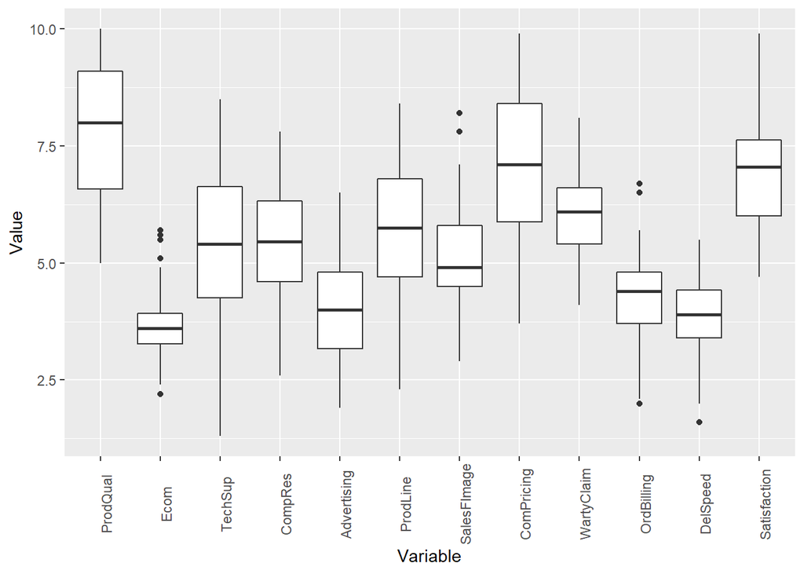

```r
ggplot(melt(Hair, id.vars = 'ID', variable.name = 'Variable', value.name = 'Value'), aes(x = Variable, y = Value)) + geom_boxplot() + theme(axis.text.x = element_text(angle = 90))
```

#### 2.3 Univariate Analysis

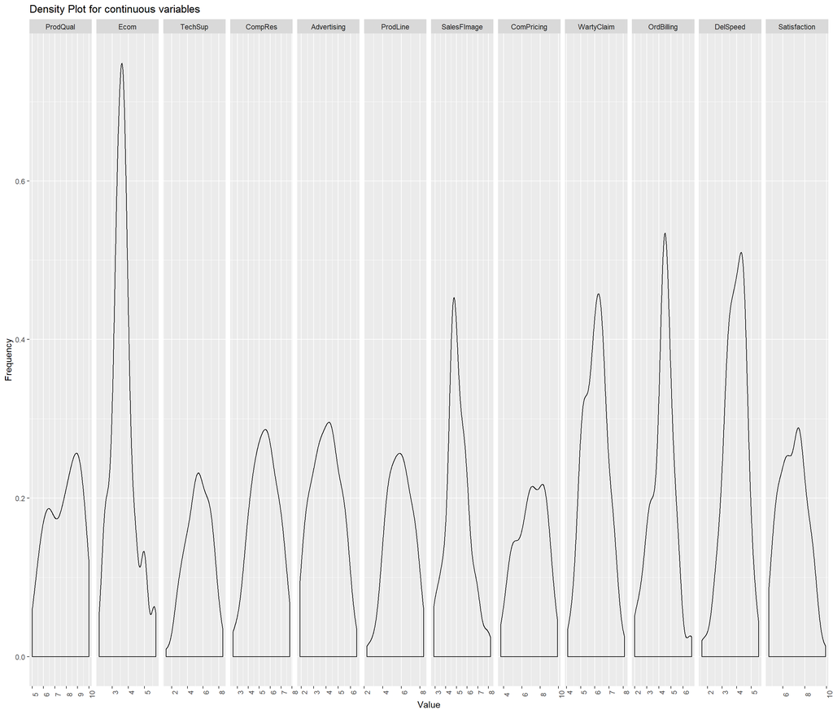

```r
ggplot(melt(Hair, id.vars = 'ID', variable.name = 'Variable', value.name = 'Value'), aes(x = Value)) + geom_density() + facet_grid(.~Variable, scales = 'free') + labs(title = 'Density Plot for continuous variables', x = 'Value', y = 'Frequency') + theme(axis.text.x = element_text(angle = 90))
```

All variables seem to have a bell shape distribution similar to a normal distribution. It is clearer for variables such as ComprRes, Advertisement, ProdLine, SalesFlmage and DelSpeed.

```r
lm_univariate <- list()

for(i in 2:(length(Hair)-1)){
lm_univariate[[names(Hair[,..i])]] <- cbind( data.table('ind_variable' = paste0(names(Hair[,..i]),'~Satisfaction')),glance(lm(paste0(names(Hair[,..i]),'~Satisfaction'), Hair)))
}

lm_univariate <- rbindlist(lm_univariate)
print(lm_univariate[,.(ind_variable, adj.r.squared, p.value)])
```

```
##                 ind_variable adj.r.squared      p.value
##  1:    ProdQual~Satisfaction   0.228721310 2.900993e-07
##  2:        Ecom~Satisfaction   0.070556424 4.367712e-03
##  3:     TechSup~Satisfaction   0.002603412 2.646933e-01
##  4:     CompRes~Satisfaction   0.357435216 3.085349e-11
##  5: Advertising~Satisfaction   0.083566586 2.056065e-03
##  6:    ProdLine~Satisfaction   0.295989611 2.953080e-09
##  7: SalesFImage~Satisfaction   0.242554383 1.164314e-07
##  8:  ComPricing~Satisfaction   0.033625738 3.755877e-02
##  9:  WartyClaim~Satisfaction   0.021639736 7.719560e-02
## 10:  OrdBilling~Satisfaction   0.264777700 2.601982e-08
## 11:    DelSpeed~Satisfaction   0.326171437 3.300472e-10
```

#### 2.4 Bi-Variate Analysis

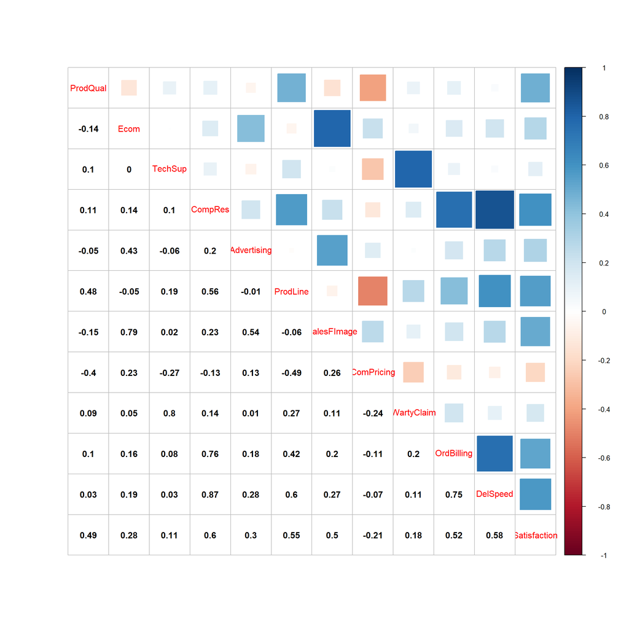

```r
cormatrix <- cor(Hair[, -c('ID')])
corrplot.mixed(cormatrix, upper ='square', lower.col = 'black')
```

- Ecom-SalesFlmage (0.79)
- TechSup-WartyClaim (0.8)
- CompRes-OrdBilling (0.76)
- CompRes-DelSpeed (0.87)

This might not enough since the correlation matrix only detects high pairwise correlations. However, it is possible that even when no pairwise correlations are high, several moderately correlated pairs may give rise to multi-collinearity.

Because of this, it is also important to perform an initial simple linear regression for the dependent variable with all the available independent variables.

```r
lm_I <- lm(Satisfaction ~., data = Hair[, -c('ID')])
summary(lm_I)
```

```
##
## Call:
## lm(formula = Satisfaction ~ ., data = Hair[, -c("ID")])
##
## Residuals:
##      Min       1Q   Median       3Q      Max
## -1.43005 -0.31165  0.07621  0.37190  0.90120
##
## Coefficients:
##             Estimate Std. Error t value Pr(>|t|)
## (Intercept) -0.66961    0.81233  -0.824  0.41199
## ProdQual     0.37137    0.05177   7.173 2.18e-10 ***
## Ecom        -0.44056    0.13396  -3.289  0.00145 **
## TechSup      0.03299    0.06372   0.518  0.60591
## CompRes      0.16703    0.10173   1.642  0.10416
## Advertising -0.02602    0.06161  -0.422  0.67382
## ProdLine     0.14034    0.08025   1.749  0.08384 .
## SalesFImage  0.80611    0.09775   8.247 1.45e-12 ***
## ComPricing  -0.03853    0.04677  -0.824  0.41235
## WartyClaim  -0.10298    0.12330  -0.835  0.40587
## OrdBilling   0.14635    0.10367   1.412  0.16160
## DelSpeed     0.16570    0.19644   0.844  0.40124
## ---
## Signif. codes:  0 '***' 0.001 '**' 0.01 '*' 0.05 '.' 0.1 ' ' 1
##
## Residual standard error: 0.5623 on 88 degrees of freedom
## Multiple R-squared:  0.8021, Adjusted R-squared:  0.7774
## F-statistic: 32.43 on 11 and 88 DF,  p-value: < 2.2e-16
```

The first thing that can be observed in the model is that the Adjusted R-squared is ok but not the best (0.7774) and in addition to this that the p_value is quite low. When looking at individual variables, we can see that only for Prod Qual, Ecom and SalesFImage have p values that are under 0.05 which means that it is unlikely we will observe a relationship between the predictor and response variables due to chance. This however, can’t be said from the other variables. However, P values where low when looking at univariable models performed above.

This suggests that there is collinearity within the independent variables that has to be addressed.

```r
vif(lm_I)
```

```
##    ProdQual        Ecom     TechSup     CompRes Advertising    ProdLine
##    1.635797    2.756694    2.976796    4.730448    1.508933    3.488185
## SalesFImage  ComPricing  WartyClaim  OrdBilling    DelSpeed
##    3.439420    1.635000    3.198337    2.902999    6.516014
```

In addition to this, we perform a Variance Inflation Factor or VIF test to the data. From the VIF test, we see that only DelSpeed has a value greater than 5 indicating it is substantially correlated with the other predictor variables.

### 3. Principal component or Factor Analysis

#### 3.1 PCA

PCA or principal component analysis is used to reduce the number of variables into specific components and it can also help with multicorrelation between independent variables. However, it is not useful when trying to measure unobserved (latent) relationships between the variables.

Because of this, EFA is more suitable for this project. However, we will perform some steps of PCA to explain why it should not be used in this case.

After this, we run a pca without rotation and make a scree plot:

```r
pc1 = psych::principal(Hair[,c(2:12)], nfactors = length(Hair[,c(2:12)]), rotate="none")
print(pc1)
```

```
## Principal Components Analysis
## Call: psych::principal(r = Hair[, c(2:12)], nfactors = length(Hair[,
##     c(2:12)]), rotate = "none")
## Standardized loadings (pattern matrix) based upon correlation matrix
##               PC1   PC2   PC3   PC4   PC5   PC6   PC7   PC8   PC9  PC10
## ProdQual     0.25 -0.50 -0.08  0.67  0.18  0.42 -0.12 -0.07 -0.01 -0.02
## Ecom         0.31  0.71  0.31  0.28  0.33 -0.20 -0.04  0.06  0.24 -0.10
## TechSup      0.29 -0.37  0.79 -0.20 -0.02  0.08  0.01 -0.23  0.16  0.14
## CompRes      0.87  0.03 -0.27 -0.22  0.02  0.02  0.01 -0.26 -0.04 -0.19
## Advertising  0.34  0.58  0.11  0.33 -0.63  0.15  0.04  0.03  0.07 -0.01
## ProdLine     0.72 -0.45 -0.15  0.21  0.09 -0.07  0.39  0.17  0.04  0.09
## SalesFImage  0.38  0.75  0.31  0.23  0.16 -0.08  0.00 -0.08 -0.29  0.13
## ComPricing  -0.28  0.66 -0.07 -0.35  0.19  0.53  0.20  0.05  0.04  0.02
## WartyClaim   0.39 -0.31  0.78 -0.19 -0.03  0.10  0.02  0.22 -0.14 -0.16
## OrdBilling   0.81  0.04 -0.22 -0.25  0.02  0.09 -0.42  0.18  0.04  0.11
## DelSpeed     0.88  0.12 -0.30 -0.21 -0.03 -0.02  0.15 -0.03  0.01  0.04
##              PC11 h2      u2 com
## ProdQual    -0.06  1 7.8e-16 3.3
## Ecom        -0.02  1 5.6e-16 3.3
## TechSup      0.02  1 1.0e-15 2.3
## CompRes      0.11  1 2.9e-15 1.7
## Advertising  0.03  1 4.4e-16 3.4
## ProdLine     0.12  1 1.1e-15 3.0
## SalesFImage  0.03  1 1.1e-15 2.8
## ComPricing   0.03  1 4.4e-16 3.4
## WartyClaim  -0.04  1 1.2e-15 2.5
## OrdBilling   0.06  1 1.8e-15 2.1
## DelSpeed    -0.24  1 1.1e-16 1.7
##
##                        PC1  PC2  PC3  PC4  PC5  PC6  PC7  PC8  PC9 PC10
## SS loadings           3.43 2.55 1.69 1.09 0.61 0.55 0.40 0.25 0.20 0.13
## Proportion Var        0.31 0.23 0.15 0.10 0.06 0.05 0.04 0.02 0.02 0.01
## Cumulative Var        0.31 0.54 0.70 0.80 0.85 0.90 0.94 0.96 0.98 0.99
## Proportion Explained  0.31 0.23 0.15 0.10 0.06 0.05 0.04 0.02 0.02 0.01
## Cumulative Proportion 0.31 0.54 0.70 0.80 0.85 0.90 0.94 0.96 0.98 0.99
##                       PC11
## SS loadings           0.10
## Proportion Var        0.01
## Cumulative Var        1.00
## Proportion Explained  0.01
## Cumulative Proportion 1.00
##
## Mean item complexity =  2.7
## Test of the hypothesis that 11 components are sufficient.
##
## The root mean square of the residuals (RMSR) is  0
##  with the empirical chi square  0  with prob <  NA
##
## Fit based upon off diagonal values = 1
```

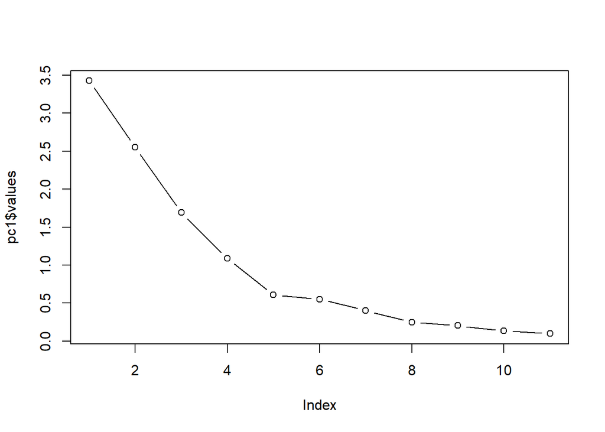

```r
plot(pc1$values, type = 'b')
```

If we follow Kaiser’s criterion and only take those points with SS Loadings > 1 then we would have 4 components. However, when running the model with 4 components we get that not all communalities are >.7. Because of this, we adjust the number of factors to 6 and add rotation:

```r
pc2 = psych::principal(Hair[,c(2:12)], nfactors = 6, rotate="varimax", scores = TRUE)
print(pc2)
```

```
## Principal Components Analysis
## Call: psych::principal(r = Hair[, c(2:12)], nfactors = 6, rotate = "varimax",
##     scores = TRUE)
## Standardized loadings (pattern matrix) based upon correlation matrix
##               RC1   RC2   RC3   RC4   RC6   RC5   h2    u2 com
## ProdQual     0.05 -0.09  0.04  0.97 -0.18  0.00 0.98 0.023 1.1
## Ecom         0.07  0.95  0.00 -0.05  0.06  0.09 0.92 0.076 1.0
## TechSup      0.02  0.00  0.94  0.03 -0.11 -0.04 0.90 0.100 1.0
## CompRes      0.93  0.08  0.05  0.04 -0.06  0.05 0.88 0.118 1.0
## Advertising  0.14  0.33 -0.03 -0.01  0.04  0.93 0.99 0.008 1.3
## ProdLine     0.61 -0.04  0.14  0.44 -0.46 -0.09 0.80 0.199 2.9
## SalesFImage  0.15  0.88  0.06 -0.07  0.14  0.27 0.89 0.109 1.3
## ComPricing  -0.07  0.17 -0.17 -0.19  0.93  0.03 0.96 0.044 1.2
## WartyClaim   0.11  0.05  0.94  0.04 -0.09  0.01 0.90 0.096 1.1
## OrdBilling   0.87  0.06  0.09  0.04  0.02  0.06 0.77 0.226 1.0
## DelSpeed     0.94  0.13 -0.01 -0.02 -0.06  0.11 0.92 0.084 1.1
##
##                        RC1  RC2  RC3  RC4  RC6  RC5
## SS loadings           2.94 1.85 1.83 1.17 1.16 0.97
## Proportion Var        0.27 0.17 0.17 0.11 0.11 0.09
## Cumulative Var        0.27 0.44 0.60 0.71 0.81 0.90
## Proportion Explained  0.30 0.19 0.18 0.12 0.12 0.10
## Cumulative Proportion 0.30 0.48 0.67 0.79 0.90 1.00
##
## Mean item complexity =  1.3
## Test of the hypothesis that 6 components are sufficient.
##
## The root mean square of the residuals (RMSR) is  0.04
##  with the empirical chi square  13.99  with prob <  0.0073
##
## Fit based upon off diagonal values = 0.99
```

If we do a correlation matrix on the PCA scores we can see that there is no correlation between the factors. This is because in PCA all the variance in the data is used to reach a solution. However, EFA is used for identifying and measuring variables that cannot be measured directly (i.e., latent variables or factors) which is what we require in this project. Because of this, we will perform a Factor Analysis.

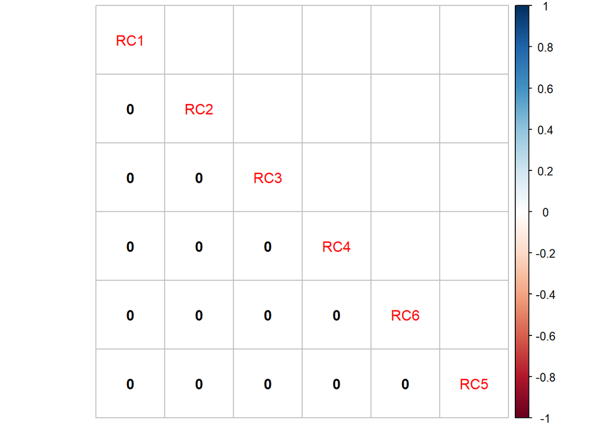

```r
corrplot.mixed(cor(pc2$scores), upper ='square', lower.col = 'black')
```

#### 3.1 EFA

For factor analysis, we first need to define the number of factors to use. One way to do this is by using Psych package:

```r
Parallel <- fa.parallel(Hair[,c(2:12)], fm = 'minres', fa = 'fa')
```

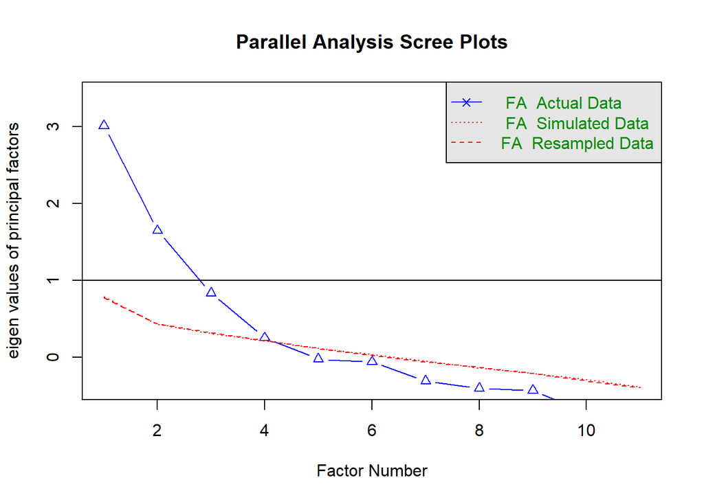

```
## Parallel analysis suggests that the number of factors =  3  and the number of components =  NA
```

Point inflection where the gap between simulated data and actual data tends to be minimum happens on 4 factors.

We run the factor analysis with 4 factors and use oblimin as rotations since we believe that there is correlation in the factors.

```r
fourfactor <- fa(Hair[,c(2:12)],nfactors = 4,rotate = "oblimin",fm="minres")
print(fourfactor)
```

```
## Factor Analysis using method =  minres
## Call: fa(r = Hair[, c(2:12)], nfactors = 4, rotate = "oblimin", fm = "minres")
## Standardized loadings (pattern matrix) based upon correlation matrix
##               MR1   MR2   MR3   MR4   h2     u2 com
## ProdQual    -0.18  0.04 -0.06  0.72 0.42 0.5759 1.1
## Ecom        -0.02  0.80  0.00  0.00 0.63 0.3706 1.0
## TechSup     -0.04 -0.03  0.90 -0.01 0.81 0.1941 1.0
## CompRes      0.91 -0.01  0.02  0.03 0.84 0.1575 1.0
## Advertising  0.11  0.52 -0.07  0.01 0.31 0.6870 1.1
## ProdLine     0.34 -0.01  0.03  0.71 0.80 0.1994 1.4
## SalesFImage  0.00  1.00  0.02  0.00 1.00 0.0049 1.0
## ComPricing   0.08  0.14 -0.15 -0.59 0.44 0.5568 1.3
## WartyClaim   0.04  0.05  0.88  0.01 0.80 0.1975 1.0
## OrdBilling   0.78  0.00  0.06 -0.01 0.62 0.3781 1.0
## DelSpeed     0.97  0.03 -0.04 -0.01 0.94 0.0578 1.0
##
##                        MR1  MR2  MR3  MR4
## SS loadings           2.59 1.95 1.66 1.42
## Proportion Var        0.24 0.18 0.15 0.13
## Cumulative Var        0.24 0.41 0.56 0.69
## Proportion Explained  0.34 0.26 0.22 0.19
## Cumulative Proportion 0.34 0.60 0.81 1.00
##
##  With factor correlations of
##      MR1   MR2  MR3   MR4
## MR1 1.00  0.25 0.12  0.36
## MR2 0.25  1.00 0.04 -0.20
## MR3 0.12  0.04 1.00  0.26
## MR4 0.36 -0.20 0.26  1.00
##
## Mean item complexity =  1.1
## Test of the hypothesis that 4 factors are sufficient.
##
## The degrees of freedom for the null model are  55  and the objective function was  6.55 with Chi Square of  619.27
## The degrees of freedom for the model are 17  and the objective function was  0.33
##
## The root mean square of the residuals (RMSR) is  0.02
## The df corrected root mean square of the residuals is  0.03
##
## The harmonic number of observations is  100 with the empirical chi square  3.18  with prob <  1
## The total number of observations was  100  with Likelihood Chi Square =  30.27  with prob <  0.024
##
## Tucker Lewis Index of factoring reliability =  0.921
## RMSEA index =  0.096  and the 90 % confidence intervals are  0.032 0.139
## BIC =  -48.01
## Fit based upon off diagonal values = 1
## Measures of factor score adequacy
##                                                    MR1  MR2  MR3  MR4
## Correlation of (regression) scores with factors   0.98 1.00 0.95 0.91
## Multiple R square of scores with factors          0.97 1.00 0.89 0.83
## Minimum correlation of possible factor scores     0.94 0.99 0.79 0.65
```

Now we need to consider the loadings more than 0.5 and not loading on more than one factor:

```r
print(fourfactor$loadings,cutoff = 0.5)
```

```
##
## Loadings:
##             MR1    MR2    MR3    MR4
## ProdQual                          0.718
## Ecom                0.798
## TechSup                    0.904
## CompRes      0.907
## Advertising         0.521
## ProdLine                          0.706
## SalesFImage         0.997
## ComPricing                       -0.591
## WartyClaim                 0.885
## OrdBilling   0.781
## DelSpeed     0.970
##
##                  MR1   MR2   MR3   MR4
## SS loadings    2.540 1.927 1.639 1.363
## Proportion Var 0.231 0.175 0.149 0.124
## Cumulative Var 0.231 0.406 0.555 0.679
```

From the above, we can see that no variables have become insignificant and that there is no double loading.

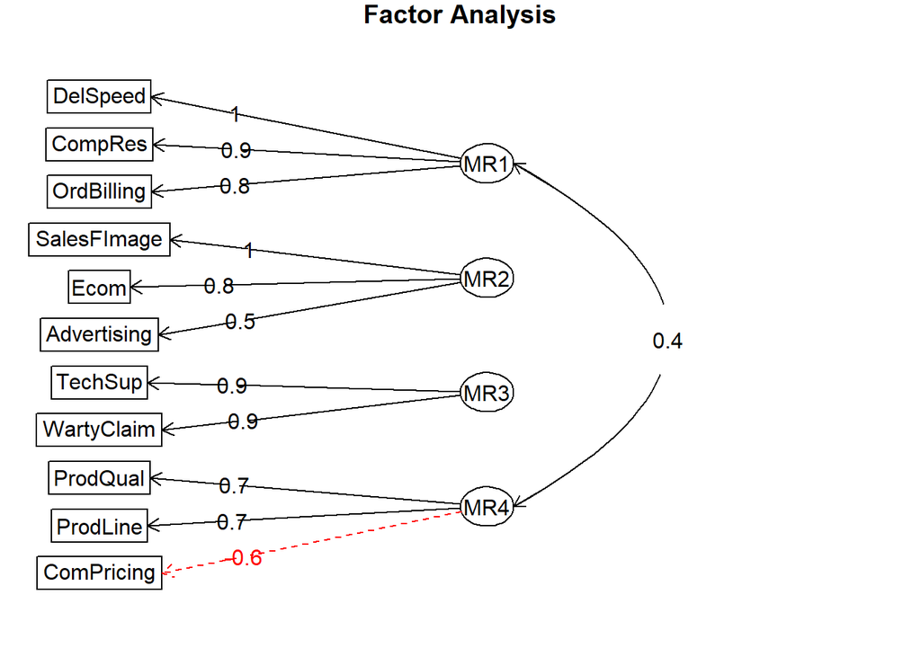

```r
fa.diagram(fourfactor)
```

Looking at the 4 factors created, we will proceed to add them to the data and rename them

```r
Hair <- cbind(Hair, fourfactor$scores)
setnames(Hair, c('MR1', 'MR2', 'MR3', 'MR4'), c('Customer_Service', 'Sales_Marketing', 'Tech_Support', 'Product'))
head(Hair,6)
```

| ID | ProdQual | Ecom | TechSup | CompRes | Advertising | ProdLine | SalesFImage | ComPricing | WartyClaim | OrdBilling | DelSpeed | Satisfaction | Customer_Service | Sales_Marketing | Tech_Support | Product |
| --- | --- | --- | --- | --- | --- | --- | --- | --- | --- | --- | --- | --- | --- | --- | --- | --- |
| 1 | 8.5 | 3.9 | 2.5 | 5.9 | 4.8 | 4.9 | 6.0 | 6.8 | 4.7 | 5.0 | 3.7 | 8.2 | -0.04032896 | 0.8250743 | -1.6928335658 | -0.2493052 |
| 2 | 8.2 | 2.7 | 5.1 | 7.2 | 3.4 | 7.9 | 3.1 | 5.3 | 5.5 | 3.9 | 4.9 | 5.7 | 1.32966920 | -1.9314981 | -0.3982490388 | 1.2280742 |
| 3 | 9.2 | 3.4 | 5.6 | 5.6 | 5.4 | 7.4 | 5.8 | 4.5 | 6.2 | 5.4 | 4.5 | 8.9 | 0.64021702 | 0.7134250 | 0.2365438783 | 1.3115778 |
| 4 | 6.4 | 3.3 | 7.0 | 3.7 | 4.7 | 4.7 | 4.5 | 8.8 | 7.0 | 4.3 | 3.0 | 4.8 | -1.31011673 | -0.5479768 | 1.0598006392 | -0.7425855 |
| 5 | 9.0 | 3.4 | 5.2 | 4.6 | 2.2 | 6.0 | 4.5 | 6.8 | 6.1 | 4.5 | 3.5 | 7.1 | -0.49227247 | -0.5353189 | -0.0005963583 | 0.3604995 |
| 6 | 6.5 | 2.8 | 3.1 | 4.1 | 4.0 | 4.3 | 3.7 | 8.5 | 5.1 | 3.6 | 3.3 | 4.7 | -0.93899974 | -1.2767749 | -1.3638275744 | -1.0618820 |

We then proceed to creating a lm model with the new factors

```r
lm_final <- lm(Satisfaction ~ Customer_Service + Sales_Marketing + Tech_Support + Product, Hair)
summary(lm_final)
```

```
##
## Call:
## lm(formula = Satisfaction ~ Customer_Service + Sales_Marketing +
##     Tech_Support + Product, data = Hair)
##
## Residuals:
##      Min       1Q   Median       3Q      Max
## -1.70781 -0.47233  0.08959  0.41930  1.35539
##
## Coefficients:
##                  Estimate Std. Error t value Pr(>|t|)
## (Intercept)       6.91800    0.06659 103.889  < 2e-16 ***
## Customer_Service  0.31908    0.07997   3.990  0.00013 ***
## Sales_Marketing   0.65886    0.07514   8.768 7.07e-14 ***
## Tech_Support     -0.06310    0.07491  -0.842  0.40170
## Product           0.71193    0.09015   7.897 4.96e-12 ***
## ---
## Signif. codes:  0 '***' 0.001 '**' 0.01 '*' 0.05 '.' 0.1 ' ' 1
##
## Residual standard error: 0.6659 on 95 degrees of freedom
## Multiple R-squared:  0.7004, Adjusted R-squared:  0.6878
## F-statistic: 55.54 on 4 and 95 DF,  p-value: < 2.2e-16
```

Adjusted R squeare is 0.6878 which is not great but it explains 68% of the variance in the data. In addition to this, the overall p.value of the model is low which implies that the null hypothesis can be rejected. When looking at the factors created, we can see that all factors but Tech Support have very low p.values which means that they can be used to predict Satisfaction. Tech Support on the other hand has a p.value of 0.4 which suggests that this variable could be dropped from the model.

The below graph shows actuals vs predictions. As it can be seen, the model does a descent job in predicting satisfaction but the overall accuracy is not great.

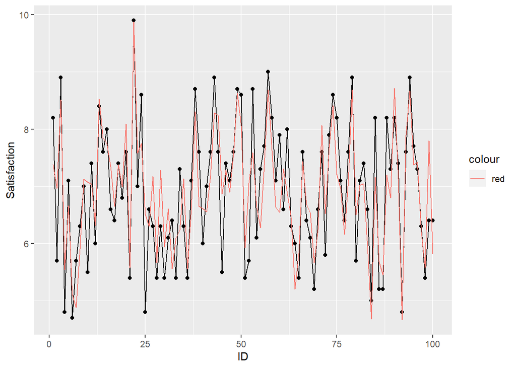

```r
Hair$Prediction <- Predict(lm_final)
ggplot(Hair, aes(x = ID, y = Satisfaction)) + geom_line() + geom_point() + geom_line(aes(x = ID, y = Prediction, col = 'red'))
```